# Newton’s Method

Gary Mitchell

2026-10-05

Newton’s method is a numerical method for finding the (approximate) roots of a function. The method is pretty straightforward. We proceed iteratively from one step to the next, starting with a current guess $x_n$:

$$x_{n+1} = x_n -
\frac{f(x_n)}{f'(x_n)}$$
In each iteration, the *step size* is the ratio of the function evaluated at the current guess, $x_n$.

## Example: Finding root with Newton’s method

For example, we can find the roots of

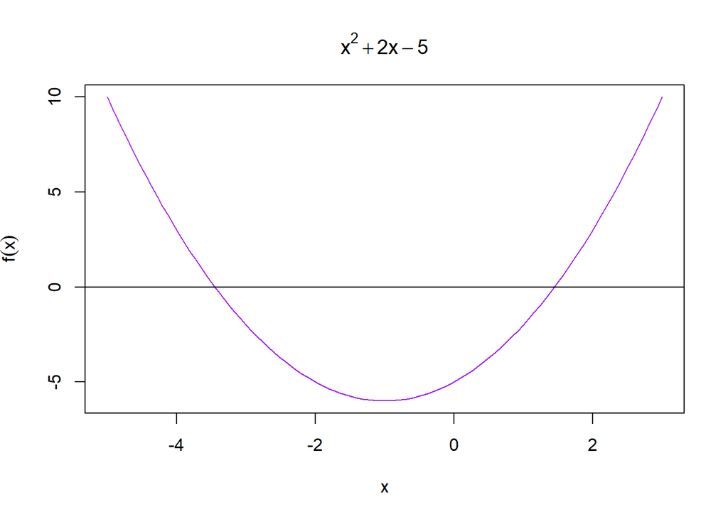

First, we find $f'(x)$:

$$f'(x) = \frac{df(x)}{dx} =
\frac{d}{dx}(x^2 + 2x - 5) = 2x + 2$$

Let’s start at $x_0$ = 6, just to give us room to observe a few iterations:

```python
import numpy as np
import pandas as pd
import math

def newtons(f, grad, initial_guess, iter_limit=100, epsilon=0.0001):

  x = np.full(iter_limit + 1, np.nan)
  fx = np.full(iter_limit + 1, np.nan)
  fpx = np.full(iter_limit + 1, np.nan)
  step = np.full(iter_limit + 1, np.nan)
  x[0] = initial_guess

  for i in range(0, len(x) - 1):
    fx[i] = f(x[i])
    fpx[i] = grad(x[i])
    step[i] = - fx[i] / fpx[i]
    x[i+1] = x[i] + step[i]

    if math.isclose(f(x[i+1]), 0, abs_tol=epsilon) or \
       math.isclose(x[i+1] - x[i], 0, abs_tol=epsilon):
      n = np.arange(i+2)
      df = pd.DataFrame({'n': n,
                         '$x_n$': x[:i+2],
                         '$f(x)$': fx[:i+2],
                         "$f'(x)$": fpx[:i+2],
                         'Step Size': step[:i+2]})
      return(df)

  return math.nan
```

In the *newtons* function, we use a for loop to ensure algorithm termination; if the loop terminates without converging to a solution, the function returns *math.nan*. The code leaves out some usual error checking (i.e., checking for a zero derivative to avoid zero divide errors) in the interest of emphasizing the *functional* code for the algorithm.

We’ll use 6 as our initial guess.

```python
initial_guess = 6


def f(x):
  return x**2 + 2 * x - 5

def grad(x):
  return 2 * x + 2

df = newtons(f, grad, initial_guess)
```

Example 1.

| n | $x_n$ | $f(x)$ | $f'(x)$ | Step Size |
| --- | --- | --- | --- | --- |
| 0 | 6.000000 | 43.0000000 | 14.000000 | -3.0714286 |
| 1 | 2.928571 | 9.4336735 | 7.857143 | -1.2006494 |
| 2 | 1.727922 | 1.4415589 | 5.455844 | -0.2642229 |
| 3 | 1.463699 | 0.0698137 | 4.927398 | -0.0141685 |
| 4 | 1.449531 | 0.0002007 | 4.899061 | -0.0000410 |
| 5 | 1.449490 | NaN | NaN | NaN |

Because we started on the right side, we found the right root. Let’s start on the left to find the left root:

```python
initial_guess = -6


def f(x):
  return x**2 + 2 * x - 5

def grad(x):
  return 2 * x + 2

df = newtons(f, grad, initial_guess)
```

Example 2.

| n | $x_n$ | $f(x)$ | $f'(x)$ | Step Size |
| --- | --- | --- | --- | --- |
| 0 | -6.000000 | 19.0000000 | -10.000000 | 1.9000000 |
| 1 | -4.100000 | 3.6100000 | -6.200000 | 0.5822581 |
| 2 | -3.517742 | 0.3390245 | -5.035484 | 0.0673271 |
| 3 | -3.450415 | 0.0045329 | -4.900830 | 0.0009249 |
| 4 | -3.449490 | NaN | NaN | NaN |

As you can see, the method converges pretty quickly. We also see that the step size automatially adjusts in every iteration, becoming closer and closer to zero (and thereby avoiding overshooting the root).

## Intuition

The graph below helps provide intuition on Newton’s method’s approach. Starting with initial guess $x_0 = 6.0$, we see that the tangent line when $x_0 = 6$ intersects the horizontal axis at $x_1 = 2.9285714$.

At each step, the value of $x_n$ becomes closer to the root and the *step size* (i.e., the difference between $x_{n+1}$ and $x_n$) becomes smaller.

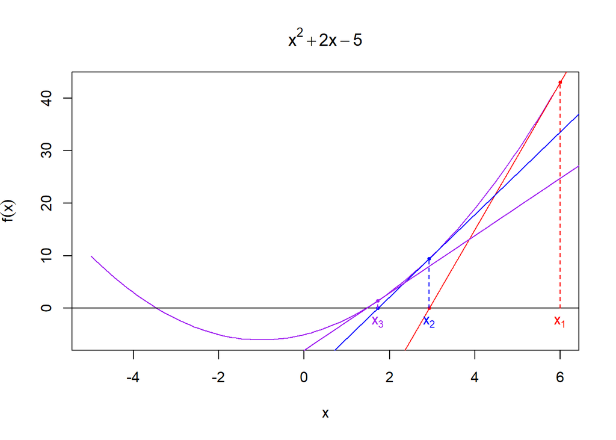

## Using Newton’s Method to find a Supremum

If the function to be optimized is strictly convex or strictly concave, then Newton’s Method can be used to find the global supremum (i.e., minimum or maximum).

Because Newton’s method finds the root(s) of a function (i.e., the value of $x$ where $f(x)=0$), we can use it to find $x : f'(x) = 0$. In other words, we use Newton’s Method to find the value of $x^*$ where the slope of the tangent line at $x^*$ is 0.

To do this, we apply Newton’s Method as described above, but now we calculate the value of $x_n$ in each iteration using:

$$x_{n+1} = x_n -
\frac{f'(x_n)}{f''(x_n)}$$

where $f''(x_n) = \frac{d^2}{dx^2}$. In other words, we find the root of the *derivative of $f(x)$. To proceed, we find the second derivative of our function:

$$f"(x) = \frac{d^2f(x)}{dx^2} =
\frac{df'(x)}{dx} = \frac{d}{dx}2x + 2 = 2$$
Since we previously defined *grad* to calculate the first derivative, we’ll define *grad2* to calculate the second derivative:

```python
initial_guess = 6

def grad2(x):
  return 2

df = newtons(grad, grad2, initial_guess)
```

Example 3.

| n | $x_n$ | $f(x)$ | $f'(x)$ | Step Size |
| --- | --- | --- | --- | --- |
| 0 | 6 | 14 | 2 | -7 |
| 1 | -1 | NaN | NaN | NaN |

Well, that wasn’t very exciting. Newton’s method converged to the optimal solution, $x^* = -1$ in 1 iteration. In fact, Newton’s method will converge to the global optimum for any quadratic.

Let’s try something a little more interesting.

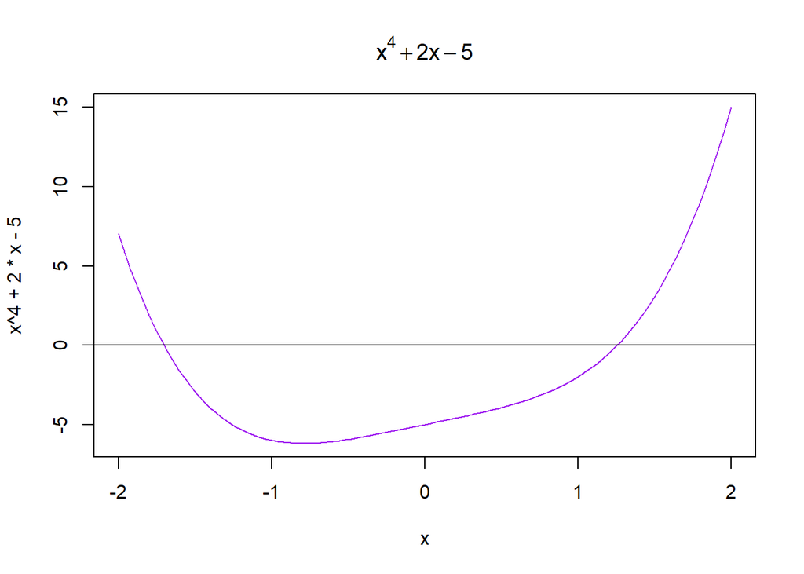

```python
initial_guess = 6


def f(x):
  return x**4 + 2 * x - 5

def grad(x):
  return 4 * x**3 + 2

def grad2(x):
  return 12 * x**2

df = newtons(grad, grad2, initial_guess)
```

Example 4.

| n | $x_n$ | $f(x)$ | $f'(x)$ | Step Size |
| --- | --- | --- | --- | --- |
| 0 | 6.0000000 | 8.660000e+02 | 4.320000e+02 | -2.0046296 |
| 1 | 3.9953704 | 2.571121e+02 | 1.915558e+02 | -1.3422309 |
| 2 | 2.6531394 | 7.670337e+01 | 8.446979e+01 | -0.9080569 |
| 3 | 1.7450825 | 2.325729e+01 | 3.654376e+01 | -0.6364231 |
| 4 | 1.1086594 | 7.450727e+00 | 1.474951e+01 | -0.5051509 |
| 5 | 0.6035085 | 2.879246e+00 | 4.370671e+00 | -0.6587652 |
| 6 | -0.0552566 | 1.999325e+00 | 3.663950e-02 | -54.5674246 |
| 7 | -54.6226812 | -6.518951e+05 | 3.580365e+04 | 18.2075045 |
| 8 | -36.4151767 | -1.931536e+05 | 1.591278e+04 | 12.1382665 |
| 9 | -24.2769101 | -5.723017e+04 | 7.072420e+03 | 8.0920206 |
| 10 | -16.1848895 | -1.695657e+04 | 3.143408e+03 | 5.3943269 |
| 11 | -10.7905626 | -5.023650e+03 | 1.397235e+03 | 3.5954228 |
| 12 | -7.1951398 | -1.487971e+03 | 6.212404e+02 | 2.3951606 |
| 13 | -4.7999792 | -4.403623e+02 | 2.764776e+02 | 1.5927592 |
| 14 | -3.2072200 | -1.299612e+02 | 1.234351e+02 | 1.0528705 |
| 15 | -2.1543495 | -3.799526e+01 | 5.569466e+01 | 0.6822064 |
| 16 | -1.4721431 | -1.076175e+01 | 2.600646e+01 | 0.4138104 |
| 17 | -1.0583327 | -2.741619e+00 | 1.344082e+01 | 0.2039771 |
| 18 | -0.8543556 | -4.944569e-01 | 8.759082e+00 | 0.0564508 |
| 19 | -0.7979048 | -3.195120e-02 | 7.639825e+00 | 0.0041822 |
| 20 | -0.7937226 | -1.672000e-04 | 7.559948e+00 | 0.0000221 |
| 21 | -0.7937005 | NaN | NaN | NaN |

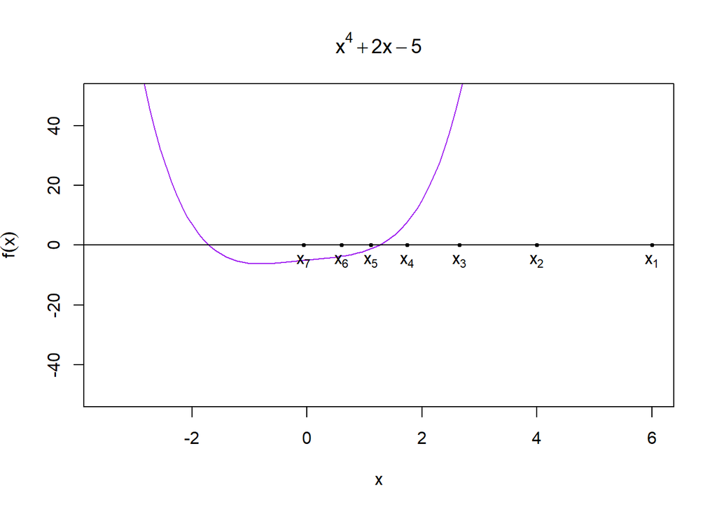

Actually, the graph is a little misleading with respect to how the algorithm converges on the optimal solution. For example, by iteration 8, $x_8 = -54.6226812$!

Clearly, the algorithm overshot the optimal solution (which we can clearly see lies in the interval $(-2, 0)$. The figure below shows the algorithm’s progress as it gets closer to the optimal solution.

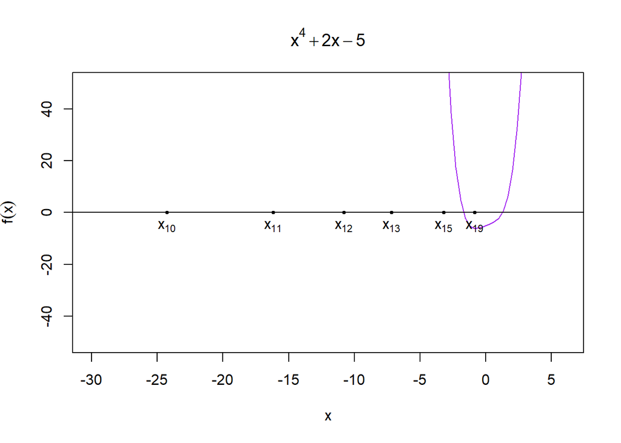

Finally, the graph below shows the optimal solution.

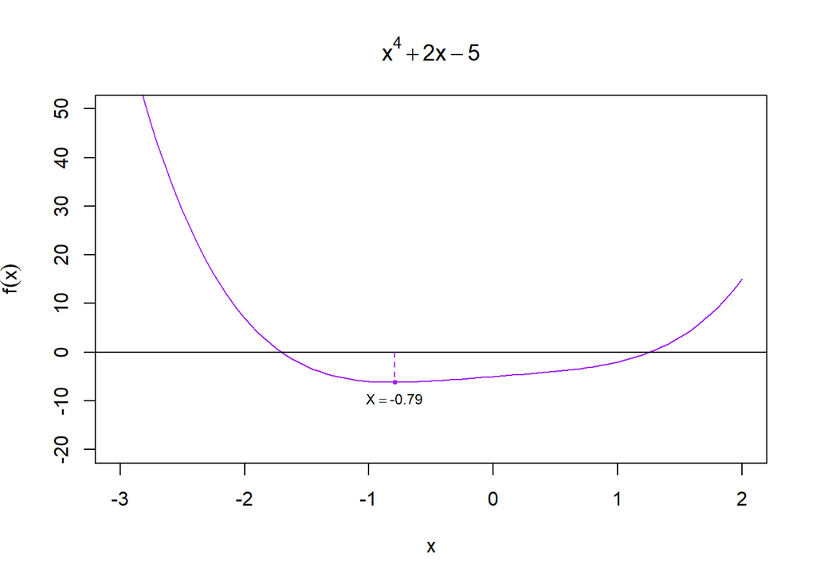

## Higher Dimension Newton’s method

Using Newton’s Method in higher dimensions can be challenging. Conceptually the method for finding the roots of a function same as with one dimension:

$$\mathbf{x}_{k+1} = \mathbf{x}_k -
[J_f(\mathbf{x}_k)]^{-1}\nabla f(\mathbf{x}_k)$$

where $\mathbf{x}_k = \{x_1, x_2, \dots, x_n\}$ is the vector of decision variables, $\nabla f(\mathbf{x}_k)$ represents the gradient of $f(\mathbf{x})$ evaluated at $\mathbf{x}_k$, and $J_f(\mathbf{x_k})$ is the Jacobian matrix of $f(\mathbf{x})$ evaluated at $\mathbf{x}_k$; a Jacobian contains all of the first-order partial derivatives of a vector-valued function.

For optimization, we use:

$$\mathbf{x}_{k+1} = \mathbf{x}_k -
[H_f(\mathbf{x}_k)]^{-1}\nabla f(\mathbf{x}_k)$$
where $H_f(\mathbf{x}_k)$ is the Hessian matrix of $f(\mathbf{x})$ evaluated at $\mathbf{x}_k$; a Hessian matrix contains all second-order partial derivatives of a vector-valued function.

Relax, we’re not going to use higher-order Newton’s Method. Calculating the inverse Hession matrix can be extremely computationally expensive. I’ve included this brief discussion just for your awareness and for context (for other method’s we’ll learn/use).